# Using Packrat

08/10/2017

## Outline

- What is packrat and why would you want to use it?
- How to use packrat (common commands, workflows, etc.)
- Using packrat in our repositories
- How to hand-off a packrat project to a client

## What is `packrat` and why would you want to use it?

## What is `packrat`?

- Packrat is a dependency management system for R
  1. Reproducible
     - records exact package versions
  2. Isolated
     - installing new or updated package from one project won't break your other projects and vice versa
  3. Portable
     - can easily transport projects from one computer to another, even across different platforms (Windows, Mac, Linux)

## Reproducibility

- Packrat helps solve this problem by:
  - Ensuring package sources are stored alongside your project
  - Tracking package versions

## Isolation

- Without packrat, when you install an R package, it gets installed into a global library
  - This can be problematic if you have older projects that depend on older versions of packages
    - i.e. a project depends on older versions of dplyr, but you want to use newer versions of dplyr
- Packrat gives each project its own private packrat library
  - if you use packrat to manage an R project, it will tell R to use and load packages from the project's *private* packrat library instead of the global library
  - When you use `install.packages()` the packages will install to the *private* *packrat* *library* if the project is managed by packrat
  - Analogy: R packages are like "books"; they live in a "library" and hence you check them out with the `library()` function

## Portability

- If you are working with collaborators/clients, you can ensure that everyone working on a Packrat project is using the same version of any R packages that your project depends on.

## How to use packrat in RStudio

## Using packrat

- Two key components:
  - Snapshot of your project's R dependencies
  - The private packrat library powering your project
- Two key verbs for interacting with these components:
  - `packrat::snapshot()`
    - records the package versions used by the project and downloads their source code for storage with the project
  - `packrat::restore()`
    - applies the previous snapshot to a directory
    - use when you first open a packrat project (that someone else started) to install all of the needed packages
    - use in case you accidentally remove a package that is needed for the project

## Overview

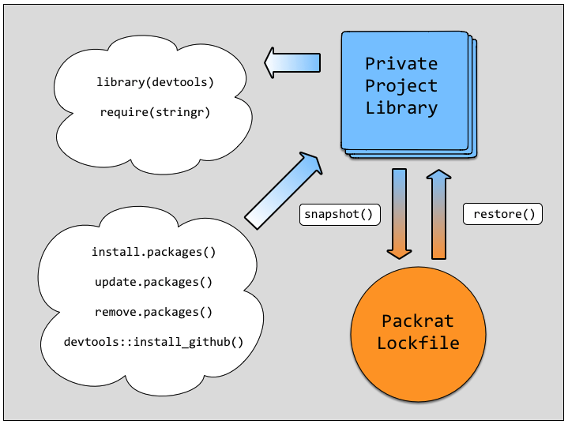

## `packrat::init()`

- sets up packrat in an existing project

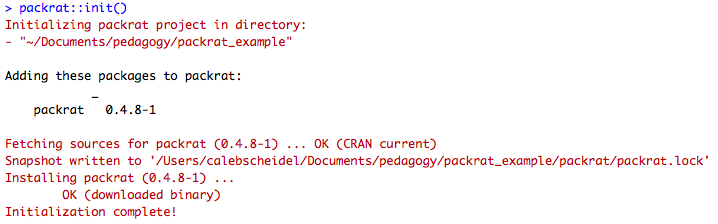

- Note: once you have made the project a packrat project, you will need to install all needed packages, even if they are installed on your global library

## `packrat::status()`

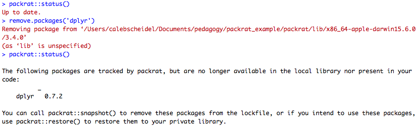

## `packrat::restore()`

- Applies the most recent snapshot to the project's private library (pulling from the `packrat.lock` file)
- works by adding, removing, and changing packages so that the set of installed packages and their versions on the current local private packrat library matches the snapshot exactly
- Three common use cases for `packrat::restore()`:
  - Hydrate - use `restore()` after copying a project to a new machine to populate the library on that machine
  - Sync - Use `restore()` to apply library changes made by a collaborator to your own library (In general, you want to run `restore()` whenever you pick up a change to `packrat.lock`)
  - Rollback - use `restore()` to undo accidental changes

## `packrat::restore()`

- After removing `dplyr` from our library, what if we wanted to get it back and written in our lockfile? We would use `packrat::restore()`:

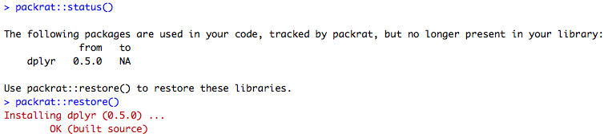

## `packrat::clean()`

- Removes packages from the library that are installed but not needed for your project
- Example: We installed a package called `pscl` and do not end up using it anywhere in the project. To remove it from the packrat library, use `packrat::clean()`:

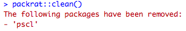

- Remember: package removes aren't auto-snapshotted, so save your changes to packrat.lock using `packrat::snapshot()` after you are finished cleaning your library

## Moving in and out of packrat mode

- `packrat::off()`
  - Gets out of packrat mode, i.e. if you want to use stuff in your global library
- `packrat::on()`
  - Gets back into packrat mode

## Other things to know

- All base R packages are already installed and versioned in the private packrat library when you set up packrat in your project
  - in `lib-R` directory
  - All loaded packages go into the `lib` and `src` directory
- You can view your packrat options with `packrat::get_opts()` and change them with `packrat::set_opts()`
- Packrat file structure:

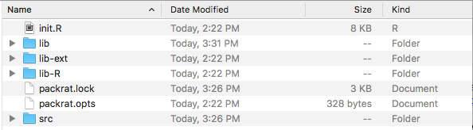

## Best practices

- Install packages on-the-fly while working
- When you are ready to push a commit and merge your branch, use `packrat::snapshot()` and `packrat::clean()` to solidify dependencies

## How to hand off a `packrat` project to a client

## Collaboration with `packrat`

- Once a project is ready to be shared with a collaborator or client, it can be "bundled" up using the `packrat::bundle()` function.
- This "bundled" project can then be shared and opened on a client's machine, with all the the packages and dependencies automatically installed when they open the `.Rproj` file or run the `packrat::unbundle()` function.

## `packrat::bundle()`

- Bundles the entire project into a gzipped tarball (`.tar.gz`) file to share with collaborators/clients
  - There are options to include the `src` and `lib` directories:
    - `packrat::bundle(include.src = FALSE, include.lib = FALSE)`
  - Currently, not aware of a way to exclude a certain subdirectory or `.Rmd` file

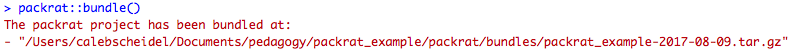

- You can then send this zipped file to the client, and if they have R/RStudio installed they can access it.

## `packrat::unbundle()`

- Unbundles the `.tar.gz` file into a new directory on the collaborator/client's machine in the exact same version as the project was bundled, with the same versions of packages and dependencies installed
- This automatically happens when the collaborator unzips/opens the `.tar.gz` file and opens the `.Rproj` file on their machine for the first time

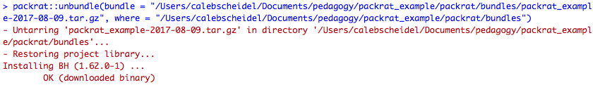

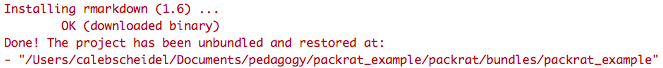

## Using `packrat` in our repositories

## `packrat` with RStudio Projects

- There are three ways we have considered using packrat in our repositories:
  1. One Repo, One `.Rproj` in top level directory, one top-level packrat folder
  2. Multiple nested `.Rproj`'s in eachsubirectory but one top-level packrat folder
  3. Multiple nested `.Rproj`'s in each subdirectory and packrat in each subdirectory (with real code in it)

## One Repo, One `.Rproj`, One Packrat

- Pros:
  - You don't have to have a separate `.Rprofile` in each subdirectory to point to higher level packrat directory
  - RStudio is aware of packrat when you are working in any subdirectory
- Cons:
  - Have to remember to set working directory to where you are currently working (usually not the top level)

## Multiple nested `.Rproj`'s but one top-level packrat

- Pros:
  - workflow "makes sense", one `.Rproj` for every subdirectory you work in to keep smaller not closely related projects separated
  - only need to keep the `packrat.lock` file as a record of dependencies should generally work
- Cons:
  - RStudio does not know you are "inheriting" packrat
  - currently unable to figure out how to get the sub-project to use the higher-level packrat directory properly, even when using `source("../.Rprofile", chdir = TRUE)`
  - lose access to the RStudio integrations in the Packages view

## Multiple nested `.Rproj`'s, where each has it's own packrat

- Pros:
  - workflow "makes sense", one `.Rproj` for every subdirectory you work in to keep smaller not closely related projects separated
  - only need to keep the `packrat.lock` file as a record of dependencies should generally work
  - Since each `.Rproj` has its own packrat, you can bundle up just one subdirectory, i.e. "final client report", instead of the entire directory to send to client
- Cons:
  - would have to set the `src/` to get git ignored so we don't explode our repos in size
  - everytime someone makes a new subdirectory, they have to make sure to set up packrat again

## Other Issues

- `formatR` package being removed from `packrat::clean()` but needing to be reinstalled every time you knit
  - This is an issue with RStudio: https://github.com/rstudio/packrat/issues/354, it doesn't see formatR as a true dependency, because none of the `library` calls in the project depend on `formatR`
  - one potential workaround is listing this as an "External package", with `packrat::set_opts(external.packages = c("formatR"))`
- `packrat::clean(dry.run = TRUE)` returns things invisibly, when there are actually packages that need to be cleaned up
- using packrat across multiple different R versions (i.e. 3.4.0 vs 3.4.1) updates `packrat.lock` file with the different version when dependencies change
  - So far, hasn't caused any *real* issues, other than some "x was built under R 3.4.0" warnings, but something to keep an eye on in the future

## What should we `.gitignore`?

- Should we keep `src/` bundled with our projects or `.gitignore` it?
  - Keep?
    - Pros:
      - it's nice to have all of the sources bundled up in the repo
        - might have advantages for building containers for packrat-enabled projects (but we're not there quite yet)
      - potentially increases speed of install?
    - Cons:
      - Massively increases the size of our repos
      - can get noisy MR's because someone may have edited one file, but brought in 4 new dependencies, so you get another file changed for each
      - forces everyone to install from source rather than pulling from binaries where able

## What should we `.gitignore`?

- Should we keep `src/` bundled with our projects or `.gitignore` it?
  - `.gitignore`?
    - Pros:
      - Decreases the size of our repos
    - Cons:
      - private packages we develop could be tricky to work with (could probably force-add the source just for those ones)
      - possible something could be removed from CRAN/Github and you can't download it later
      - potentially decreases speed of download/install
- Note: use `packrat::set_opts(vcs.ignore.src = TRUE)` to add `src/` to `.gitignore`

## References

- Packrat Documentation:
  - https://rstudio.github.io/packrat/
- Kevin Ushey's RStudio webinar:
  - https://www.rstudio.com/resources/webinars/managing-package-dependencies-in-r-with-packrat/
- Brian Connelly's Blog:
  - http://bconnelly.net/2014/07/creating-reproducible-software-environments-with-packrat/
- Nishant Upadhyay's post:
  - http://rstudio-pubs-static.s3.amazonaws.com/221948_fb7215fecb0d49ac903f701fd8d45132.html